# json

Fernando Velasco

25/12/2014

En este ejercicio se mostrará la lectura de datos en Json (y una pequeña historia de los mismos) desde una API online.

Se ha elegido la API de [data.gov](http://www.data.gov/), que es una de las mas usuales. He tratado de no repetir con la de worldbank por intentar aprender un poco mas de las distintas APIs disponibles.

Se ha elegido un dataset temporal de desastres naturales en Estados Unidos, y concretamente un sampleado menor (DisasterDeclarationsSummaries) que sera interesante para evitar problemas de memoria. Esto significa que serán datos de entre 1953 y 1967. Se excluiran los de 1968 por no tener con seguridad todos los datos de ese año (el dataset esta “cortado” por ahi)

Procedemos con la lectura de datos:

```r
jotason <- readLines ("http://www.fema.gov/api/open/v1/DisasterDeclarationsSummaries")
library(rjson)
desastres <- fromJSON (jotason)
```

Un vistazo rapido a los nombres nos permite identificar donde estan nuestros datos:

```r
names (desastres)
```

```
## [1] "metadata"                      "DisasterDeclarationsSummaries"
```

```r
names (desastres$DisasterDeclarationsSummaries[[1]])
```

```
##  [1] "disasterNumber"       "ihProgramDeclared"    "iaProgramDeclared"
##  [4] "paProgramDeclared"    "hmProgramDeclared"    "state"
##  [7] "declarationDate"      "disasterType"         "incidentType"
## [10] "title"                "incidentBeginDate"    "incidentEndDate"
## [13] "declaredCountyArea"   "hash"                 "lastRefresh"
## [16] "placeCode"            "disasterCloseOutDate" "id"
```

```r
class (desastres$DisasterDeclarationsSummaries)
```

```
## [1] "list"
```

Con lo que ya podemos convertir esa lista de datos a un data table, por ejemplo:

```r
library(data.table)
# en condiciones normales seria
# dt <- rbindlist(desastres$DisasterDeclarationsSummaries, fill=TRUE)
# pero tiene valores nulos, con lo que primero hay que convertir esos nulos en NAs:
library (plyr)
dt <- as.data.table (rbind.fill(lapply(desastres$DisasterDeclarationsSummaries, function(f) {
    as.data.frame(Filter(Negate(is.null), f))
})))
```

Podemos estudiar, por ejemplo, cual es el tipo de desastre que mas se ha repetido a lo largo de los años (repetido=se ha dado al menos una vez cada año). Para ello, vamos a completar un poco nuestra tabla (sin olvidarnos de eliminar los datos de 1968)

```r
fecha <- function (desastre){
  return (format (as.Date (desastre$declarationDate), "%Y"))
}
dt$fecha <- fecha (dt)
dt$tipo <- as.factor (dt$incidentType)
dt.limpio <- dt[dt$fecha < 1968]
```

Vamos a mostrarlo graficamente:

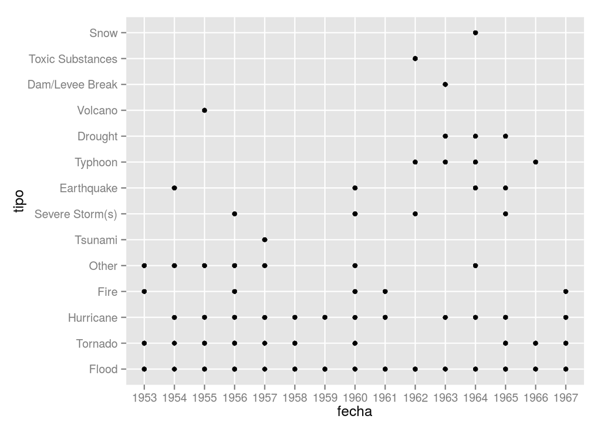

Este ploteo rapido nos dice, por ejemplo, que los mas repetidos son las inundaciones, huracanes y tornados.